# Scenario comparison

# Context

A scenario must be defined to do a performance test over a rest service. We took data from production on a Monday, to see how many requests/m should we simulate.

It turned that we have seen there are differences between a saturday and a monday, probably due to different tasks and differnete type of use of the application during weekend and working days.

Dia is the day the sample was took from.

```r
df = read.csv("uriscsv_ordinals.csv", header=T)
head(df)
```

```
##                                                                          uri
## 1           getAppVersionInfov4 (/v4/authservices/rest/version/{appVersion})
## 2               getBreakdownById (/v3/authservices/rest/breakdown/{storeId})
## 3            getCoverageByStoreId (/v3/authservices/rest/coverage/{storeId})
## 4 getCoverageChartByStoreId (/v3/authservices/rest/coverage/{storeId}/chart)
## 5      getCriteriaType (/v3/authservices/rest/filter/{storeId}/criteriaType)
## 6                        getFilters (/v3/authservices/rest/filter/{storeId})
##   count      dia uriNominal
## 1   105 lunes 10          1
## 2   319 lunes 10          2
## 3   123 lunes 10          3
## 4   163 lunes 10          4
## 5    99 lunes 10          5
## 6   224 lunes 10          6
```

```r
df$uriNominal = factor(df$uriNominal)
df$uri = factor(df$uri)
library(ggplot2)
```

In this data, each uri is mapped to a uriNominal. Count is the number of requests/min that method had in that period.

Plotting a boxplot we see differences in the distribution

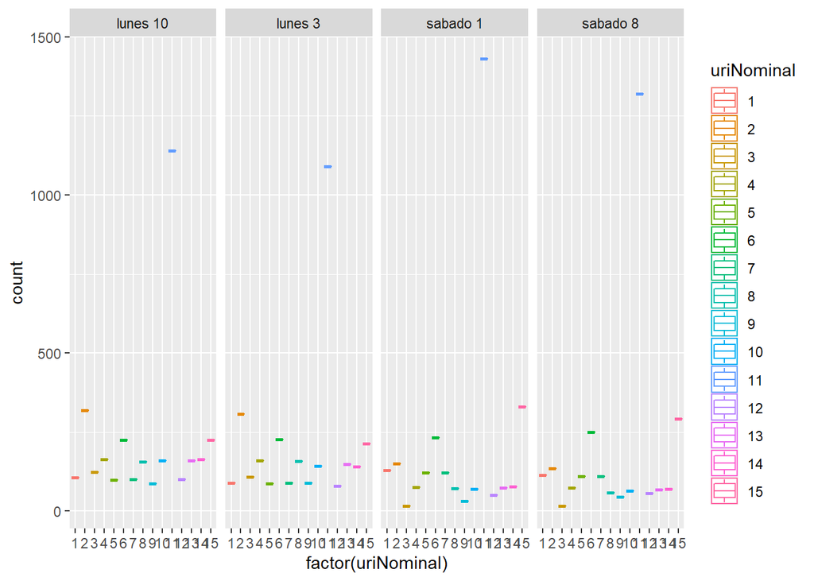

```r
ggplot(aes(x=factor(uriNominal),y=count, color=uriNominal), data = df) + geom_violin() + geom_boxplot() + facet_grid(. ~ dia)
```

# Significant differences

In order to see if there’s a significant difference between samples, we will try a chi squared test for homogeneicity.

```r
msabado = as.table(rbind(df$count[df$dia == "sabado 8"], df$count[df$dia == "sabado 1"]))
dimnames(msabado) = list(c("sabado 8", "sabado 1"), df$uriNominal[df$dia == "sabado 8"])
chisq.test(msabado)
```

```
##
##  Pearson's Chi-squared test
##
## data:  msabado
## X-squared = 8.2123, df = 14, p-value = 0.878
```

```r
# p value is 0.87, it's greater than the signifficance level alpha = 0.05 so there's not enough evidence to reject the null hypothesis (both looks correctly proportioned)
mlunes = as.table(rbind(df$count[df$dia == "lunes 10"], df$count[df$dia == "lunes 3"]))
dimnames(mlunes) = list(c("lunes 10", "sabado 1"), df$uriNominal[df$dia == "lunes 3"])
chisq.test(mlunes)
```

```
##
##  Pearson's Chi-squared test
##
## data:  mlunes
## X-squared = 5.3073, df = 14, p-value = 0.9811
```

```r
# again, a high p-value which indicates there's no reason to reject the null hypothesis, so we don't reject that the 2 samples are equally distributed
```

Now, if we get saturday sample and compare against monday sample we get

```r
msabadolunes = as.table(rbind(df$count[df$dia == "sabado 1"], df$count[df$dia == "lunes 3"]))
dimnames(msabadolunes) = list(c("sabado 1", "lunes 3"), df$uriNominal[df$dia == "lunes 3"])
chisq.test(msabadolunes)
```

```
##
##  Pearson's Chi-squared test
##
## data:  msabadolunes
## X-squared = 371.21, df = 14, p-value < 2.2e-16
```

A p-value below significance level 0.05 suggests strong evidence against the null hypothesis (no differences at all), so we reject it. There is a signifficant difference in the frequencies.